#### **Привет, Екатерина!** 👋 Меня зовут Артём Пиляй. Я буду проверять твой проект «*Исследование A/B-тестирования нового алгоритма рекомендаций в развлекательном приложении*» 📱. --- В рамках корпоративной этики мы общаемся на «ты». Но если лучше на «Вы», то важно обозначить это сразу. --- Комментарии к проекту размещены в отдельных ячейках Markdown. Для удобства они отображаются в меню **Contents** слева. Я использую четыре типа комментариев: --- ✅ Главый комментарий — значит, всё сделано хорошо. А ещё здесь могут быть подсказки, как улучшить проект. --- ⚠️ Рекомендуемый к исправлению — лучше внести правки, хотя это не критично для текущего проекта. Но начиная со следующего проекта такие комментарии будут считаться критическими. --- ⛔ Обязателен к исправлению — важный комментарий, который нужно доработать, чтобы проект прошёл проверку. --- 🚩 Красный флаг — проверку пришлось прервать, так как действие в ячейке выше повлияло на весь дальнейший проект.

Важно! Не перемещай и не удаляй мои комментарии. Если они будут удалены, я верну последнюю версию проекта, где они сохранились.

🏁 Перейти к итогам ревью

# Разработка A/B-тестирования и анализ результатов

Вы работаете продуктовым аналитиком в компании, которая разрабатывает развлекательное приложение с функцией «бесконечной» ленты, как, например, в приложениях с короткими видео. В вашем приложении существует две модели монетизации: первая — ежемесячная платная подписка, которая позволяет пользователям смотреть ленту без рекламы, вторая — демонстрация рекламы для пользователей, которые ещё не оформили подписку.

Команда разработчиков рекомендательных систем создала новый алгоритм рекомендаций, который, по их мнению, будет показывать более интересный контент для каждого пользователя. Вас, как аналитика, просят помочь рассчитать параметры A/B-теста, который позволит проверить эту гипотезу, и проанализировать его результаты.

## Описание данных

Вы будете работать с тремя таблицами:

- `sessions_project_history.csv` — таблица с историческими данными по сессиям пользователей на период с 2025-08-11 по 2025-09-23. Путь к файлу: `/datasets/sessions_project_history.csv`.
- `sessions_project_test_part.csv` — таблица с данными за первый день проведения A/B-теста, то есть за 2025-10-14. Путь к файлу: `/datasets/sessions_project_test_part.csv`.
- `sessions_project_test.csv` — таблица с данными за весь период проведения A/B-теста, то есть с 2025-10-14 по 2025-11-02. Путь к файлу: `/datasets/sessions_project_test.csv`.

У этих таблиц почти совпадает структура и содержание колонок, различаются лишь периоды наблюдения.

Поля таблиц `sessions_project_history.csv`, `sessions_project_test.csv`, `sessions_project_test_part.csv`:

- `user_id` — идентификатор пользователя;
- `session_id` — идентификатор сессии в приложении;
- `session_date` — дата сессии;
- `session_start_ts` — дата и время начала сессии;
- `install_date` — дата установки приложения;
- `session_number` — порядковый номер сессии для конкретного пользователя;
- `registration_flag` — является ли пользователь зарегистрированным;
- `page_counter` — количество просмотренных страниц во время сессии;
- `region` — регион пользователя;
- `device` — тип устройства пользователя;
- `test_group` — тестовая группа (в таблице с историческими данными этого столбца нет).

## Что нужно сделать

Ваши задачи: рассчитать параметры теста, оценить корректность его проведения и проанализировать результаты эксперимента.

Для проведения A/B-тестирования будет измеряться количество удачных сессий. К удачным сессиям относятся сессии с количеством просмотренных страниц больше четырёх. Ожидается, что изменения, внесённые в одну из групп, приведут к увеличению количества удачных сессий по сравнению с контрольной группой.

##### ✅ Вводная часть

✅ Отлично, что уже есть вводная часть написанная в шаблоне.

⚠️ Еще можно раскрыть особенности А/В теста — изменение какой метрики ожидается, какие другие метрики будут также тестироваться и какой ожидаемый эффект

Это небольшое улучшение, которое сделают проект более презентабельным и понятным для заказчика. 😉

💬 Здесь можно оставить комментарий

### 1. Работа с историческими данными (EDA)

#### 1.1. Загрузка исторических данных

На первом этапе поработайте с историческими данными приложения:

- Импортируйте библиотеку pandas.
- Считайте и сохраните в датафрейм `sessions_history` CSV-файл с историческими данными о сессиях пользователей `sessions_project_history.csv`.

Выведите на экран первые пять строк полученного датафрейма.

```python
# Импортируем библиотеку pandas
import pandas as pd

# Импортируем библиотеку matplotlib для построения графиков
import matplotlib.pyplot as plt

# Импортируем библиотеки для статистической обработки
from statsmodels.stats.power import NormalIndPower
from statsmodels.stats.proportion import proportion_effectsize

# Импортируем необходимые библиотеки для проведения статистического теста
from scipy.stats import ttest_ind
import numpy as np

# Импортируем библиотеки для построения диаграммы Венна
!pip install matplotlib-venn -q
from matplotlib_venn import venn2
import matplotlib.pyplot as plt
import numpy as np
```

##### ⚠️ Python Enhancement Proposal №8.

⚠️ Я понимаю, что в прекоде импорты идут дальше, но согласно руководству PEP 8 лучше:

- ✅ отделять импорт от основного кода;
- ❌ импортировать все библиотеки в одной ячейке в начале проекта.

Это делает код более структурированным и понятным.

Это помогает:

- Сразу видеть, какое окружение необходимо для запуска проекта.
- Избежать дублирования импортов в разных частях кода.
- Облегчить отладку и переносимость проекта.

Подробнее о PEP 8 можно прочитать в статье [*PEP 8 - руководство по написанию кода на Python*](https://pythonworld.ru/osnovy/pep-8-rukovodstvo-po-napisaniyu-koda-na-python.html).

💬 Здесь можно оставить комментарий

⚠️ Почти отлично, только повторный импорт делать не нужно.

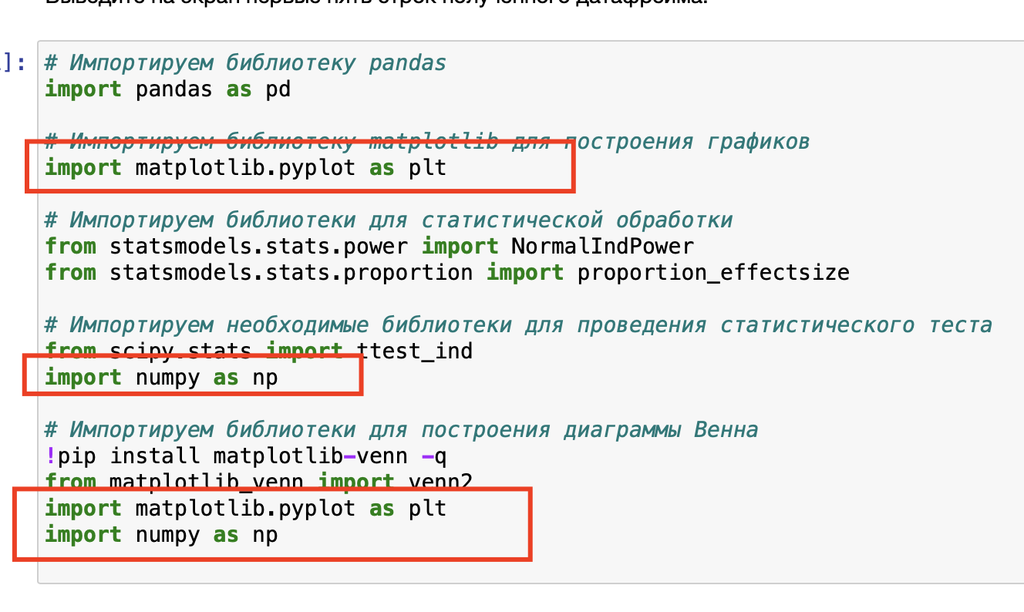

```python
# Сохраняем данные из CSV-файла в датафрейм
sessions_history = pd.read_csv('https://code.s3.yandex.net/datasets/sessions_project_history.csv')
```

```python
# Выводим первые 5 строк датафрейма 'sessions_history'
sessions_history.head()
```

|  | user_id | session_id | session_date | session_start_ts | install_date | session_number | registration_flag | page_counter | region | device |
| --- | --- | --- | --- | --- | --- | --- | --- | --- | --- | --- |
| 0 | E302123B7000BFE4 | F9AF61A0C2023832 | 2025-08-15 | 2025-08-15 17:47:35 | 2025-08-15 | 1 | 0 | 3 | CIS | iPhone |
| 1 | 2530F72E221829FB | 85003A206CBDAC6F | 2025-08-15 | 2025-08-15 16:42:14 | 2025-08-15 | 1 | 0 | 4 | MENA | Android |
| 2 | 876E020A4FC512F5 | 3677423E49D72DEE | 2025-08-15 | 2025-08-15 12:30:00 | 2025-08-15 | 1 | 0 | 4 | EU | PC |
| 3 | 2640B349E1D81584 | 956B45F5915CA225 | 2025-08-15 | 2025-08-15 15:31:31 | 2025-08-15 | 1 | 0 | 4 | CIS | Android |
| 4 | 94E1CBFAEF1F5EE9 | 83BF0DA35F9F1F40 | 2025-08-15 | 2025-08-15 21:33:53 | 2025-08-15 | 1 | 0 | 3 | CIS | Android |

```python
# Выводим информацию о датафрееме 'sessions_history'
sessions_history.info()
```

```
<class 'pandas.core.frame.DataFrame'>
RangeIndex: 435924 entries, 0 to 435923
Data columns (total 10 columns):
 #   Column             Non-Null Count   Dtype
---  ------             --------------   -----
 0   user_id            435924 non-null  object
 1   session_id         435924 non-null  object
 2   session_date       435924 non-null  object
 3   session_start_ts   435924 non-null  object
 4   install_date       435924 non-null  object
 5   session_number     435924 non-null  int64
 6   registration_flag  435924 non-null  int64
 7   page_counter       435924 non-null  int64
 8   region             435924 non-null  object
 9   device             435924 non-null  object
dtypes: int64(3), object(7)
memory usage: 33.3+ MB
```

#### 1.2. Знакомство с данными

- Для каждого уникального пользователя `user_id` рассчитайте количество уникальных сессий `session_id`.
- Выведите на экран все данные из таблицы `sessions_history` для одного пользователя с наибольшим количеством сессий. Если таких пользователей несколько, выберите любого из них.
- Изучите таблицу для одного пользователя, чтобы лучше понять логику формирования каждого столбца данных.

```python
# Подсчитываем количество уникальных сессий для каждого уникального пользователя
unique_sessions_per_user = sessions_history.groupby('user_id')['session_id'].nunique()
# Сохраняем user_id пользователя с максимальным количеством сессий
max_user_id = unique_sessions_per_user.idxmax()
# Выводим из датафрейма 'sessions_history' все данные для пользователя с наибольшим количесвом сессий
display(sessions_history[sessions_history['user_id'] == max_user_id])
```

|  | user_id | session_id | session_date | session_start_ts | install_date | session_number | registration_flag | page_counter | region | device |
| --- | --- | --- | --- | --- | --- | --- | --- | --- | --- | --- |
| 115558 | 10E0DEFC1ABDBBE0 | B8F0423BBFFCF5DC | 2025-08-14 | 2025-08-14 13:57:39 | 2025-08-14 | 1 | 0 | 4 | CIS | Android |
| 191751 | 10E0DEFC1ABDBBE0 | 87CA2FA549473837 | 2025-08-15 | 2025-08-15 16:42:10 | 2025-08-14 | 2 | 0 | 3 | CIS | Android |
| 239370 | 10E0DEFC1ABDBBE0 | 4ADD8011DCDCE318 | 2025-08-16 | 2025-08-16 19:53:21 | 2025-08-14 | 3 | 0 | 3 | CIS | Android |
| 274629 | 10E0DEFC1ABDBBE0 | DF0FD0E09BF1F3D7 | 2025-08-17 | 2025-08-17 15:03:43 | 2025-08-14 | 4 | 0 | 1 | CIS | Android |
| 302501 | 10E0DEFC1ABDBBE0 | 3C221774B4DE6885 | 2025-08-18 | 2025-08-18 17:29:14 | 2025-08-14 | 5 | 0 | 4 | CIS | Android |
| 325557 | 10E0DEFC1ABDBBE0 | 031BD7A67048105B | 2025-08-19 | 2025-08-19 13:23:55 | 2025-08-14 | 6 | 0 | 2 | CIS | Android |
| 345336 | 10E0DEFC1ABDBBE0 | FF4315CF4AD4B100 | 2025-08-20 | 2025-08-20 19:31:54 | 2025-08-14 | 7 | 0 | 2 | CIS | Android |
| 377532 | 10E0DEFC1ABDBBE0 | 4045FEA0747203B4 | 2025-08-22 | 2025-08-22 17:54:13 | 2025-08-14 | 8 | 0 | 2 | CIS | Android |
| 403538 | 10E0DEFC1ABDBBE0 | 344B086C421C7F37 | 2025-08-24 | 2025-08-24 14:46:13 | 2025-08-14 | 9 | 0 | 2 | CIS | Android |
| 414743 | 10E0DEFC1ABDBBE0 | 054F20BA371E4C9D | 2025-08-25 | 2025-08-25 18:36:41 | 2025-08-14 | 10 | 0 | 3 | CIS | Android |

##### ✅ Знакомство с данными

✅ Молодец, использование `idmax` помогает упростить и ускорить анализ данных.

Преимущества метода:

- Оптимизация кода — сокращает количество вычислений по сравнению с альтернативными методами.
- Быстродействие — позволяет находить нужное значение без дополнительной сортировки.
- Читаемость — код становится лаконичным и понятным.
- Эффективность — снижает нагрузку при обработке больших объемов данных.

Подробнее можно ознакомиться в документации по Pandas: [Pandas idxmax()](https://pandas.pydata.org/docs/reference/api/pandas.DataFrame.idxmax.html)

💬 Здесь можно оставить комментарий

#### 1.3. Анализ числа регистраций

Одна из важнейших метрик продукта — число зарегистрированных пользователей. Используя исторические данные, визуализируйте, как менялось число регистраций в приложении за время его существования.

- Агрегируйте исторические данные и рассчитайте число уникальных пользователей и число зарегистрированных пользователей для каждого дня наблюдения. Для простоты считайте, что у пользователя в течение дня бывает одна сессия максимум и статус регистрации в течение одного дня не может измениться.
- Постройте линейные графики общего числа пользователей и общего числа зарегистрированных пользователей по дням. Отобразите их на одном графике.
- Постройте отдельный линейный график доли зарегистрированных пользователей от всех пользователей по дням.
- На обоих графиках должны быть заголовок, подписанные оси X и Y, сетка и легенда.

```python
# Группировка по дате сессии и подсчёт количества пользователей и зарегистрированных пользователей
grouped = sessions_history.groupby('session_date').agg({
    'user_id': 'count',  # Подсчёт общего количества пользователей в день
    'registration_flag': 'sum'  # Подсчёт количества зарегистрированных пользователей в день
})

grouped.columns = ['total_users', 'registered_users']

display(grouped)
```

| session_date | total_users | registered_users |
| --- | --- | --- |
| 2025-08-11 | 3919 | 169 |
| 2025-08-12 | 6056 | 336 |
| 2025-08-13 | 8489 | 464 |
| 2025-08-14 | 10321 | 625 |
| 2025-08-15 | 14065 | 840 |
| 2025-08-16 | 12205 | 916 |
| 2025-08-17 | 11200 | 833 |
| 2025-08-18 | 10839 | 860 |
| 2025-08-19 | 12118 | 831 |
| 2025-08-20 | 13514 | 1008 |
| 2025-08-21 | 15051 | 1063 |
| 2025-08-22 | 17563 | 1251 |
| 2025-08-23 | 16082 | 1253 |
| 2025-08-24 | 13683 | 1181 |
| 2025-08-25 | 13635 | 1060 |
| 2025-08-26 | 13289 | 1050 |
| 2025-08-27 | 14766 | 1076 |
| 2025-08-28 | 15388 | 1175 |
| 2025-08-29 | 16873 | 1174 |
| 2025-08-30 | 14891 | 1165 |
| 2025-08-31 | 13266 | 1105 |
| 2025-09-01 | 12685 | 1028 |
| 2025-09-02 | 12672 | 1039 |
| 2025-09-03 | 12777 | 1035 |
| 2025-09-04 | 13683 | 1007 |
| 2025-09-05 | 15324 | 1030 |
| 2025-09-06 | 13078 | 1023 |
| 2025-09-07 | 12367 | 1069 |
| 2025-09-08 | 11826 | 1009 |
| 2025-09-09 | 11780 | 980 |
| 2025-09-10 | 12526 | 1015 |
| 2025-09-11 | 8623 | 824 |
| 2025-09-12 | 6436 | 669 |
| 2025-09-13 | 5183 | 537 |
| 2025-09-14 | 4364 | 440 |
| 2025-09-15 | 3698 | 383 |
| 2025-09-16 | 3032 | 286 |
| 2025-09-17 | 2548 | 272 |
| 2025-09-18 | 1952 | 201 |
| 2025-09-19 | 1418 | 132 |
| 2025-09-20 | 1100 | 107 |
| 2025-09-21 | 776 | 87 |
| 2025-09-22 | 546 | 68 |
| 2025-09-23 | 317 | 32 |

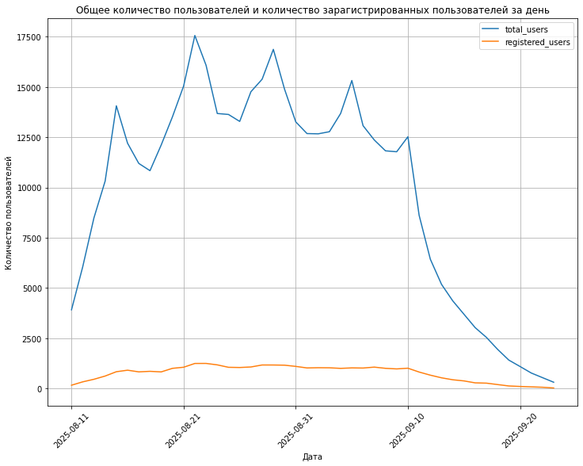

```python
# Стоим линейную диаграму на основе агрегированных данных
grouped.plot(
    kind='line',
    rot=45,
    title='Общее количество пользователей и количество зарагистрированных пользователей за день',
    xlabel='Дата',
    ylabel='Количество пользователей',
    figsize= (12, 9)
)
# Добавляем сетку на диаграмму
plt.grid(True)

# Выводим диаграмму на экран
plt.show()
```

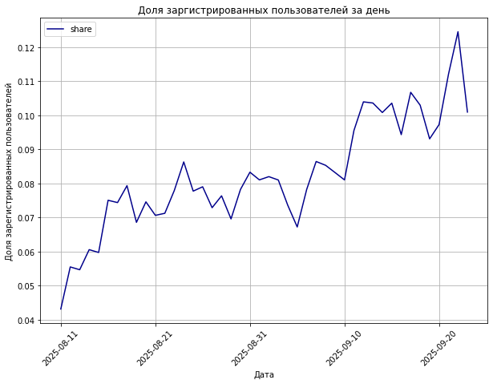

```python
# Вычисляем долю зарегистрированных пользователей за день
grouped['share']=grouped['registered_users']/grouped['total_users']

# Стоим линейную диаграму на основе агрегированных данных
grouped['share'].plot(
    kind='line',
    rot=45,
    color='darkblue',
    figsize=(10, 7),
    legend=True,
    title='Доля заргистрированных пользователей за день',
    xlabel='Дата',
    ylabel='Доля зарегистрированных пользователей'
)
# Добавляем сетку на диаграмму
plt.grid(True)

# Выводим диаграмму на экран
plt.show()
```

Доля зарегистрированных пользователей в общем числе активных пользователей за период с 11.08.2025 по 23.09.2025 увеличилась с 4% до 10–12%. При этом общее количество пользователей снизилось, однако количество зарегистрированных пользователей уменьшилось в меньшей пропорции. Такая динамика приводит к росту доли зарегистрированных пользователей, создавая эффект относительного увеличения их числа, хотя фактическое количество зарегистрированных пользователей сокращается.

##### ✅ Анализ числа регистраций

✅ Ты правильно описываешь динамику метрик, отмечая ключевые моменты.

- Верно, высокая вариативность доли может быть связана с уменьшением количества наблюдений к концу периода.
- Также стоит обратить внимание на возможную недельную цикличность и общий спад посещаемости. Эти особенности важно учитывать при планировании теста и расчете количества участников.

💬 Здесь можно оставить комментарий

#### 1.4. Анализ числа просмотренных страниц

Другая важная метрика продукта — число просмотренных страниц в приложении. Чем больше страниц просмотрено, тем сильнее пользователь увлечён контентом, а значит, выше шансы, что он зарегистрируется и оплатит подписку.

- Найдите количество сессий для каждого значения количества просмотренных страниц. Например: одну страницу просмотрели в 29 160 сессиях, две страницы — в 105 536 сессиях и так далее.
- Постройте столбчатую диаграмму, где по оси X будет число просмотренных страниц, по оси Y — количество сессий.
- На диаграмме должны быть заголовок, подписанные оси X и Y.

```python
session_pages = sessions_history.groupby('page_counter')['session_id'].count()
display(session_pages)
```

```
page_counter
1     29160
2    105536
3    166690
4    105569
5     26288
6      2589
7        92
Name: session_id, dtype: int64
```

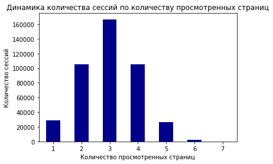

```python
session_pages.plot(
    kind='bar',
    rot=0,
    color='darkblue',
    title='Динамика количества сессий по количеству просмотренных страниц',
    xlabel='Количество просмотренных страниц',
    ylabel='Количество сессий'
)

plt.show()
```

Анализ диаграммы свидетельствует, что в большинстве сессий пользователи просматривают от 2 до 4 страниц, что указывает на средний уровень вовлечённости и типичную глубину взаимодействия с ресурсом за одну сессию.

##### ✅ Анализ числа просмотренных страниц

✅ Отлично, выбран правильный тип графика, а также добавлены название и подписи осей.

Преимущества такого подхода:

- Наглядность — столбчатая диаграмма хорошо подходит для сравнения дискретных данных.
- Читаемость — благодаря названию и подписям осей график легко интерпретировать.

Подробнее о выборе графиков можно прочитать в статье: [Matplotlib – Визуализация данных](https://matplotlib.org/stable/plot_types/index.html).

💬 Здесь можно оставить комментарий

#### 1.5. Доля пользователей, просмотревших более четырёх страниц

Продуктовая команда продукта считает, что сессии, в рамках которых пользователь просмотрел 4 и более страниц, говорят об удовлетворённости контентом и алгоритмами рекомендаций. Этот показатель является важной прокси-метрикой для продукта.

- В датафрейме `sessions_history` создайте дополнительный столбец `good_session`. В него войдёт значение `1`, если за одну сессию было просмотрено 4 и более страниц, и значение `0`, если было просмотрено меньше.
- Постройте график со средним значением доли успешных сессий от всех сессий по дням за весь период наблюдения.

```python
sessions_history['good_session'] = sessions_history['page_counter'].apply(lambda x: 1 if x >= 4 else 0)
sessions_history.head()
```

|  | user_id | session_id | session_date | session_start_ts | install_date | session_number | registration_flag | page_counter | region | device | good_session |
| --- | --- | --- | --- | --- | --- | --- | --- | --- | --- | --- | --- |
| 0 | E302123B7000BFE4 | F9AF61A0C2023832 | 2025-08-15 | 2025-08-15 17:47:35 | 2025-08-15 | 1 | 0 | 3 | CIS | iPhone | 0 |
| 1 | 2530F72E221829FB | 85003A206CBDAC6F | 2025-08-15 | 2025-08-15 16:42:14 | 2025-08-15 | 1 | 0 | 4 | MENA | Android | 1 |
| 2 | 876E020A4FC512F5 | 3677423E49D72DEE | 2025-08-15 | 2025-08-15 12:30:00 | 2025-08-15 | 1 | 0 | 4 | EU | PC | 1 |
| 3 | 2640B349E1D81584 | 956B45F5915CA225 | 2025-08-15 | 2025-08-15 15:31:31 | 2025-08-15 | 1 | 0 | 4 | CIS | Android | 1 |
| 4 | 94E1CBFAEF1F5EE9 | 83BF0DA35F9F1F40 | 2025-08-15 | 2025-08-15 21:33:53 | 2025-08-15 | 1 | 0 | 3 | CIS | Android | 0 |

```python
grouped = sessions_history.groupby('session_date').agg({'good_session': ['sum', 'count']})
grouped['good_sessions_share'] = grouped[('good_session', 'sum')] / grouped[('good_session', 'count')]
```

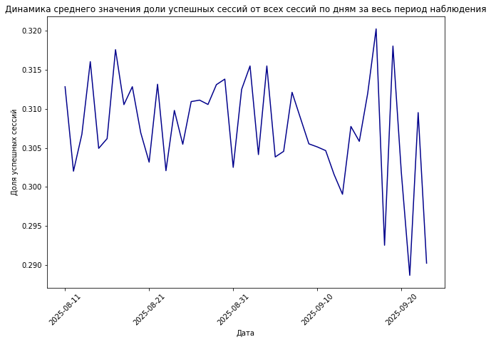

```python
grouped['good_sessions_share'].plot(
    kind='line',
    rot=45,
    title='Динамика среднего значения доли успешных сессий от всех сессий по дням за весь период наблюдения',
    xlabel='Дата',
    ylabel='Доля успешных сессий',
    color='darkblue',
    figsize=(10,7)
)

plt.show()
```

В период с 11.08.2025 по 23.09.2025 доля успешных сессий находится в диапазоне от 29% до 32%. При этом наблюдается тенденция к постепенному снижению данного показателя. Совместно с уменьшением общего числа пользователей за этот период, это может свидетельствовать о растущем уровне неудовлетворенности пользователей работой приложения.

##### ✅ Доля пользователей, просмотревших более четырёх страниц

✅ Правильно выделена доля успешных сессий.

- Верно отмечено, что к концу периода снизилось количество наблюдений, что могло повлиять на вариативность метрики.
- Можно также учитывать возможную цикличность активности пользователей, чтобы точнее планировать тесты.
- В конце периода, когда снизилось число сессий, доля успешных сессий стала более вариативной из-за меньшего количества наблюдений.

💬 Здесь можно оставить комментарий

### 2. Подготовка к тесту

При планировании теста необходимо проделать несколько важных шагов:

- Сформулировать нулевую и альтернативную гипотезы
- Определиться с целевой метрикой.
- Рассчитать необходимый размер выборки.
- Исходя из текущих значений трафика рассчитать необходимую длительность проведения теста.

#### 2.1 Формулировка нулевой и альтернативной гипотез

Перед тем как проводить А/B-тест, необходимо сформулировать нулевую и альтернативную гипотезы. Напомним изначальное условие: команда разработчиков рекомендательных систем создала новый алгоритм, который, по их мнению, будет показывать более интересный контент для каждого пользователя.

О какой метрике идёт речь? Как она будет учтена в формулировке гипотез?

Метрика - доля успешных сессий среди пользователей приложения.

Сформулируйте нулевую и альтернативную гипотезы:

Нулевая гипотеза: Доля успешных сессий среди пользователей в контрольной и тестовой группе равны. Альтернативная односторонняя гипотеза: Доля успешных сессий среди пользователей в тестовой группе больше, чем в контрольной.

##### ✅ Формулировка гипотез перед статистическим тестом

✅ Молодец, что перед проверкой теста формулируешь нулевую (H₀) и альтернативную (H₁) гипотезы. Так понятно, какие различия мы проверяем.

Подробнее можно почитать [здесь](https://allatambov.github.io/psms/pdf/hypo-test.pdf)

💬 Здесь можно оставить комментарий

#### 2.2. Расчёт размера выборки

В рамках курса вы уже рассчитывали размеры выборки и использовали для этого онлайн-калькулятор. В этом задании предлагаем воспользоваться готовым кодом и рассчитать необходимое для вашего эксперимента количество пользователей.

Для этого установите в коде ниже следующие параметры:

- Уровень значимости — 0.05.
- Вероятность ошибки второго рода — 0.2.
- Мощность теста.
- Минимальный детектируемый эффект, или MDE, — 3%. Обратите внимание, что здесь нужно указать десятичную дробь, а не процент.

При расчёте размера выборки используйте метод `solve_power()` из класса `power.NormalIndPower` модуля `statsmodels.stats`.

Запустите ячейку и изучите полученное значение.

```python
# Задаём параметры
alpha = 0.05  # Уровень значимости
beta = 0.2  # Ошибка второго рода, часто 1 - мощность
power = 0.8  # Мощность теста
p = 0.3 # Базовый уровень доли
mde = 0.03 * p  # Минимальный детектируемый эффект
effect_size = proportion_effectsize(p, p + mde)

# Инициализируем класс NormalIndPower
power_analysis = NormalIndPower()

# Рассчитываем размер выборки
sample_size = power_analysis.solve_power(
    effect_size = effect_size,
    power = power,
    alpha = alpha,
    ratio = 1 # Равномерное распределение выборок
)

print(f"Необходимый размер выборки для каждой группы: {int(sample_size)}")
```

```
Необходимый размер выборки для каждой группы: 41040
```

##### ✅ Связь ошибки II рода и мощности критерия

✅ Так же можно было явно связать ошибку второго рода и мощность критерия через `power = 1 - beta`. Это важный аспект статистического анализа, который помогает оценить вероятность обнаружения реального эффекта.

Преимущества такого подхода:

- Позволяет осознанно выбирать размер выборки для теста.
- Помогает сбалансировать риск ложных отрицательных результатов.
- Улучшает интерпретацию результатов A/B-тестирования.

Кстати, есть еще очень интересный бесплатный курс от Практикума по A/B-тестированию — там можно более детально познакомиться с расчетом длительности теста:  
[Practicum – Основы статистики](https://practicum.yandex.ru/profile/statistics-basic/)

💬 Здесь можно оставить комментарий

#### 2.3. Расчёт длительности A/B-теста

Используйте данные о количестве пользователей в каждой выборке и среднем количестве пользователей приложения. Рассчитайте длительность теста, разделив одно на другое.

- Рассчитайте среднее количество уникальных пользователей приложения в день.
- Определите длительность теста исходя из рассчитанного значения размера выборок и среднего дневного трафика приложения. Количество дней округлите в большую сторону.

```python
from math import ceil

# Среднее количество пользователей приложения в день по историческим данным
avg_daily_users = round(sessions_history.groupby('session_date')['user_id'].count().mean(), 2)

# Рассчитываем длительность теста в днях как отношение размера выборки к среднему числу пользователей
test_duration = ceil(sample_size*2/avg_daily_users)

print(f"Рассчитанная длительность A/B-теста при текущем уровене трафика в {avg_daily_users} пользователей в день составит {test_duration} дней")
```

```
Рассчитанная длительность A/B-теста при текущем уровене трафика в 9907.36 пользователей в день составит 9 дней
```

##### ✅ Расчёт длительности A/B-теста

Нужно умножить `sample_size` на 2 перед делением на `avg_daily_users`.

💬 Здесь можно оставить комментарий

✅ Все правильно, но важно понимать, что это допустимый минимальный срок, однако для повышения надёжности результатов теста желательно провести его дольше — например, на 14 дней, чтобы сгладить возможные колебания в поведении пользователей по дням недели и собрать больше данных для анализа.

### 3. Мониторинг А/В-теста

#### 3.1. Проверка распределения пользователей

- Считайте и сохраните в датафрейм `sessions_test_part` CSV-файл с историческими данными о сессиях пользователей `sessions_project_test_part.csv`.
- Рассчитайте количество уникальных пользователей в каждой из экспериментальных групп для одного дня наблюдения.
- Рассчитайте и выведите на экран процентную разницу в количестве пользователей в группах A и B. Постройте любую удобную визуализацию, на которой будет видно возможное различие двух групп.

Для расчёта процентной разницы воспользуйтесь формулой: $$P = 100 \cdot \frac{|A − B|}{A}$$

```python
# Сохраняем данные из CSV-файла в датафрейм
sessions_test_part = pd.read_csv('https://code.s3.yandex.net/datasets/sessions_project_test_part.csv')
```

```python
# Выводим первые 5 строк датафрейма 'sessions_test_part'
sessions_test_part.head()
```

|  | user_id | session_id | session_date | session_start_ts | install_date | session_number | registration_flag | page_counter | region | device | test_group |
| --- | --- | --- | --- | --- | --- | --- | --- | --- | --- | --- | --- |
| 0 | 3404844B53442747 | B4901323BD537E45 | 2025-10-14 | 2025-10-14 19:28:49 | 2025-10-14 | 1 | 0 | 3 | CIS | Android | B |
| 1 | 3A2BF4D364E62D89 | 216FC619308F8788 | 2025-10-14 | 2025-10-14 21:11:04 | 2025-10-14 | 1 | 0 | 3 | MENA | iPhone | A |
| 2 | 79CDAE11E32B1597 | EDFCE4AC1A504074 | 2025-10-14 | 2025-10-14 21:44:03 | 2025-10-14 | 1 | 0 | 3 | CIS | iPhone | A |
| 3 | D6AF8D78297A931F | CF0AC0EEDE92C690 | 2025-10-14 | 2025-10-14 19:07:55 | 2025-10-14 | 1 | 0 | 4 | CIS | PC | A |
| 4 | 37E0CE723AE568E0 | 2E6ED45E8C86C4E9 | 2025-10-14 | 2025-10-14 15:39:44 | 2025-10-14 | 1 | 0 | 3 | CIS | Mac | B |

```python
sessions_test_part.groupby('test_group')['user_id'].nunique()
```

```
test_group
A    1477
B    1466
Name: user_id, dtype: int64
```

```python
# Рассчитываем количество уникальных пользователей для каждой группы для одного дня наблюдения
# Группируем данные по дате и групппе эксперимента, подсчитываем количество уникальных пользователей
groups=sessions_test_part.groupby(['session_date','test_group'])['user_id'].nunique()

# Переводим строки групп A и B в столбцы
groups_unstacked = groups.unstack(level='test_group')

# Присваиваем значения количества уникальных пользователей переменным a и b
a = groups_unstacked.iloc[0, 0]
b = groups_unstacked.iloc[0, 1]
```

```python
# Рассчитываем процентную разницу в количестве пользователей в группах A и B
P = 100 * abs(a - b) / a
print(f'Процентная разница в количестве пользователей в группах A и B: {round(P, 2)}%')
```

```
Процентная разница в количестве пользователей в группах A и B: 0.74%
```

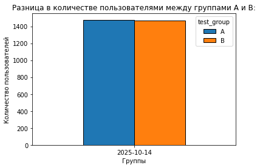

```python
# Строим график для демонстрации различия в количестве пользователями между группами A и B
groups_unstacked[['A', 'B']].plot(
    kind='bar',
    rot=0,
    title='Разница в количестве пользователями между группами A и B:',
    xlabel='Группы',
    ylabel='Количество пользователей',
    edgecolor='k'
)
# Выводим график на экран
plt.show()
```

##### ✅ Проверка распределения пользователей

$$ P = 100 \cdot \frac{|1477 - 1466|}{1477} = 100 \cdot \frac{11}{1477} \approx 0.745% $$

💬 Здесь можно оставить комментарий

✅ Все правильно.

#### 3.2. Проверка пересечений пользователей

Помимо проверки равенства количества пользователей в группах, полезно убедиться в том, что группы независимы. Для этого нужно убедиться, что никто из пользователей случайно не попал в обе группы одновременно.

- Рассчитайте количество пользователей, которые встречаются одновременно в группах A и B, или убедитесь, что таких нет.

```python
# Проверяем наличие явных дубликатов
sessions_test_part['session_id'].duplicated().sum()
```

```
0
```

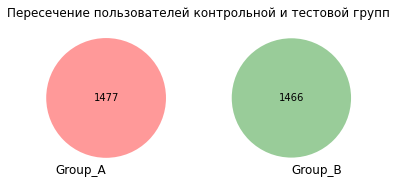

```python
# Преобразование датафреймов в множества для сравнения
set1 = set(sessions_test_part[sessions_test_part['test_group'] == 'A']['user_id'])
set2 = set(sessions_test_part[sessions_test_part['test_group'] == 'B']['user_id'])

# Создание диаграммы Венна
venn2([set1, set2], set_labels=('Group_A', 'Group_B'))


# Отображаем график
plt.title("Пересечение пользователей контрольной и тестовой групп")
plt.show()
```

##### ✅ Проверка пересечений пользователей между группами

✅ Альтернативный способ — использовать группировку, что может быть полезно при работе с большими данными:

```
sessions_test_part.groupby('user_id').agg({'test_group': 'nunique'}).query('test_group > 1')
```

Этот метод позволяет сразу отфильтровать пользователей, которые встречаются в обеих группах.

💬 Здесь можно оставить комментарий

#### 3.3. Равномерность разделения пользователей по устройствам

Полезно также убедиться в том, что пользователи равномерно распределены по всем доступным категориальным переменным — типам устройств и регионам.

Постройте две диаграммы:

- доля каждого типа устройства для пользователей из группы A,
- доля каждого типа устройства для пользователей из группы B.

Постарайтесь добавить на диаграммы все необходимые подписи, пояснения и заголовки, которые позволят сделать вывод о том, совпадает ли распределение устройств в группах A и B.

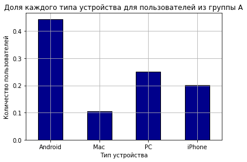

```python
# Подсчитываем количество уникальных пользователей по каждому устройству
unique_users_by_device = sessions_test_part[sessions_test_part['test_group'] == 'A'].groupby('device')['user_id'].nunique()

# Нормализуем данные, чтобы получить доли
device_shares = unique_users_by_device / unique_users_by_device.sum()

device_shares.plot(
    kind='bar',
    rot=0,
    color='darkblue',
    edgecolor='k',
    xlabel='Тип устройства',
    ylabel='Количество пользователей',
    title='Доля каждого типа устройства для пользователей из группы A'
)

# Добавляем сетку на график
plt.grid()

# Выыодим график на экран
plt.show()
```

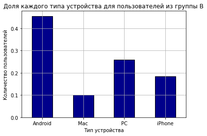

```python
# Подсчитываем количество уникальных пользователей по каждому устройству
unique_users_by_device = sessions_test_part[sessions_test_part['test_group'] == 'B'].groupby('device')['user_id'].nunique()

# Нормализуем данные, чтобы получить доли
device_shares = unique_users_by_device / unique_users_by_device.sum()

device_shares.plot(
    kind='bar',
    rot=0,
    color='darkblue',
    edgecolor='k',
    xlabel='Тип устройства',
    ylabel='Количество пользователей',
    title='Доля каждого типа устройства для пользователей из группы B'
)

# Добавляем сетку на график
plt.grid()

# Выыодим график на экран
plt.show()
```

##### ⛔️ Расчёт распределения пользователей

- по устройствам 👆
- и регионам 👇

Важно учитывать число уникальных пользователей для каждого устройства а этом шаге и регионов в следующем.

Ориентиры:

|  | A | B |
| --- | --- | --- |
| Android | 44.4 | 45.5 |
| Mac | 10.5 | 10.1 |
| PC | 24.9 | 25.9 |
| iPhone | 20.0 | 18.3 |

|  | A | B |
| --- | --- | --- |
| CIS | 43.6 | 44.0 |
| EU | 15.2 | 14.8 |
| MENA | 41.2 | 41.2 |

💬 Здесь можно оставить комментарий

⛔️ Странные регионый. =)

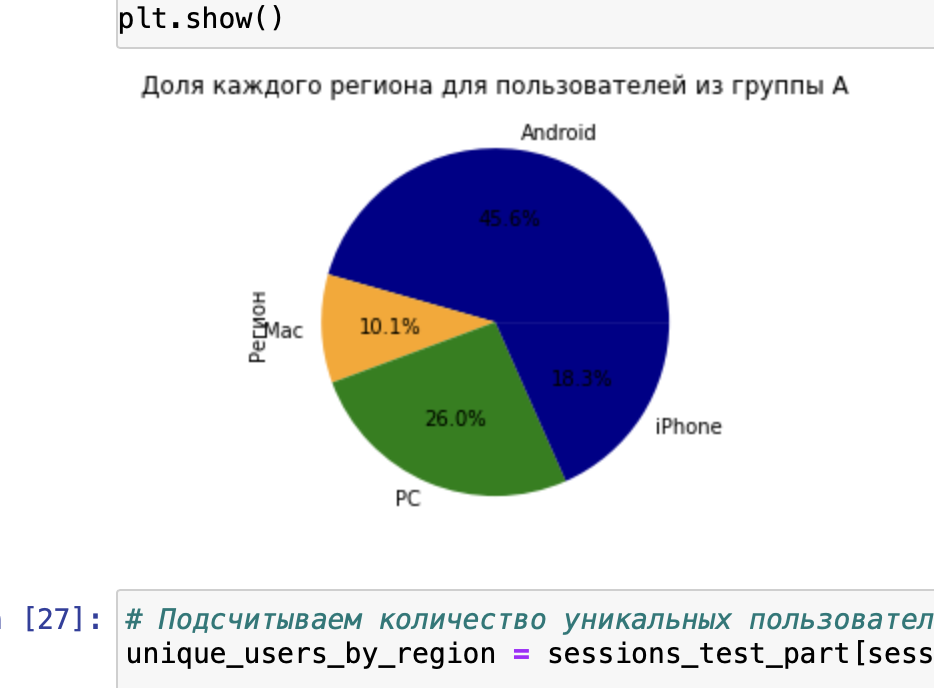

#### 3.4. Равномерность распределения пользователей по регионам

Теперь убедитесь, что пользователи равномерно распределены по регионам.

Постройте две диаграммы:

- доля каждого региона для пользователей из группы A,
- доля каждого региона для пользователей из группы B.

Постарайтесь добавить на диаграммы все необходимые подписи, пояснения и заголовки, которые позволят сделать вывод о том, совпадает ли распределение регионов в группах A и B. Постарайтесь использовать другой тип диаграммы, не тот, что в прошлом задании.

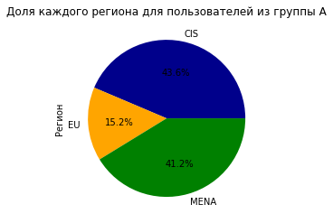

```python
# Подсчитываем количество уникальных пользователей по каждому устройству
unique_users_by_region = sessions_test_part[sessions_test_part['test_group'] == 'A'].groupby('region')['user_id'].nunique()

# Нормализуем данные, чтобы получить доли
region_shares = unique_users_by_region / unique_users_by_device.sum()


# Задаем цвета для каждого региона
colors = ['darkblue', 'orange', 'green']

# Строим круговую диаграмму распределения пользователей по регионам в группе А
region_shares.plot(
    kind='pie',
    title='Доля каждого региона для пользователей из группы A',
    ylabel='Регион',
    colors=colors,
    autopct='%1.1f%%'
)

# Выыодим график на экран
plt.show()
```

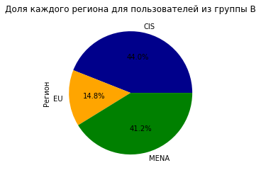

```python
# Подсчитываем количество уникальных пользователей по каждому устройству
unique_users_by_region = sessions_test_part[sessions_test_part['test_group'] == 'B'].groupby('region')['user_id'].nunique()

# Нормализуем данные, чтобы получить доли
region_shares = unique_users_by_region / unique_users_by_device.sum()


# Задаем цвета для каждого региона
colors = ['darkblue', 'orange', 'green']

# Строим круговую диаграмму распределения пользователей по регионам в группе B
region_shares.plot(
    kind='pie',
    title='Доля каждого региона для пользователей из группы B',
    ylabel='Регион',
    colors=colors,
    autopct='%1.1f%%',
    normalize=True
)

# Выыодим график на экран
plt.show()
```

#### 3.5. Вывод после проверки A/B-теста

На основе проведённого анализа A/B-теста сформулируйте и запишите свои выводы. В выводе обязательно укажите:

- Было ли обнаружено различие в количестве пользователей в двух группах.
- Являются ли выборки независимыми. Было ли обнаружено пересечение пользователей из тестовой и контрольной групп.
- Сохраняется ли равномерное распределение пользователей тестовой и контрольной групп по категориальным переменным: устройствам и регионам.

Сделайте заключение: корректно ли проходит A/B-тест, или наблюдаются какие-либо нарушения.

1. Разница в количестве пользователей между двумя группами составляет 0.74%, что является допустимым, поскольку размер групп достаточен для проведения A/B-тестирования.
2. Диаграмма Венна показывает отсутствие пересечений по пользователям между группами A и B.
3. Анализ распределения пользователей по типам устройств демонстрирует, что оно относительно равномерное в обеих группах. Наибольшее количество пользователей использует Android и PC, в то время как количество пользователей с устройствами Iphone и Mac меньше. Распределение пользователей по регионам также является равномерным.

##### ⚠️ Вывод после проверки A/B-теста

⚠️ В A/B-тестировании важно, чтобы распределение пользователей по группам было максимально равномерным — особенно при оценке долей (например, конверсий).

Отклонение в 5% и более между размерами групп считается критичным, так как оно может:чй

- исказить метрики (например, если одна группа в 1.5 раза больше другой — её вклад в суммарные значения будет непропорционален);
- снизить статистическую мощность теста;
- повлиять на интерпретацию результатов (особенно если наблюдается эффект, обусловленный размером группы, а не самим изменением в продукте).

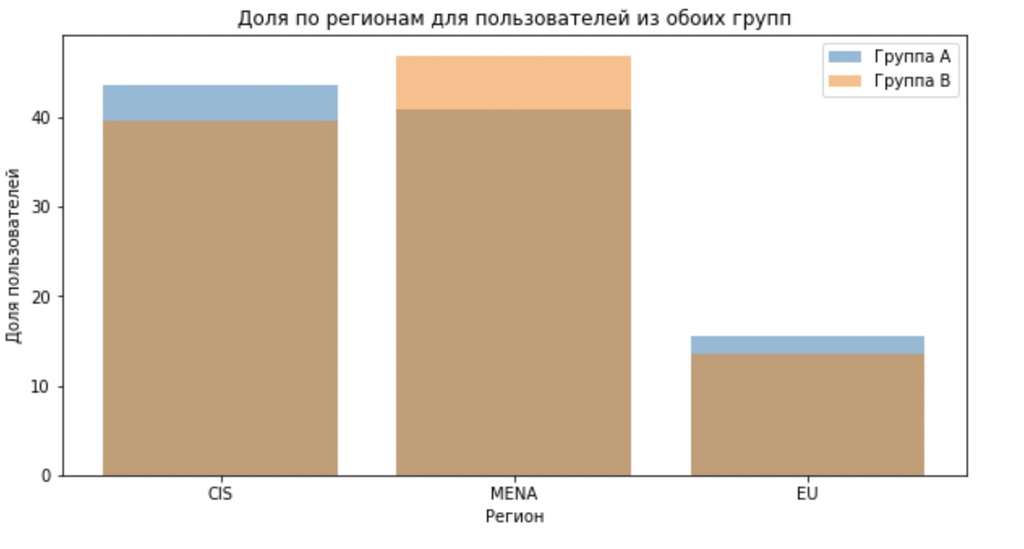

Однако в данном случае дисбаланс, показанный на графике, вызван ошибкой в расчётах. После их исправления распределение между группами окажется корректным — и первоначальный вывод (что дисбаланс критичен) перестаёт быть актуальным.

💬 Здесь можно оставить комментарий

### 4. Проверка результатов A/B-теста

A/B-тест завершён, и у вас есть результаты за все дни проведения эксперимента. Необходимо убедиться в корректности теста и верно интерпретировать результаты.

#### 4.1. Получение результатов теста и подсчёт основной метрики

- Считайте и сохраните в датафрейм `sessions_test` CSV-файл с историческими данными о сессиях пользователей `sessions_project_test.csv`.
- В датафрейме `sessions_test` создайте дополнительный столбец `good_session`. В него войдёт значение `1`, если за одну сессию было просмотрено 4 и более страниц, и значение `0`, если просмотрено меньше.

```python
# Сохраняем данные из CSV-файла в датафрейм
sessions_test = pd.read_csv('https://code.s3.yandex.net/datasets/sessions_project_test.csv')
```

```python
# Выводим первые 5 строк датафрейма 'sessions_test'
sessions_test.head()
```

|  | user_id | session_id | session_date | session_start_ts | install_date | session_number | registration_flag | page_counter | region | device | test_group |
| --- | --- | --- | --- | --- | --- | --- | --- | --- | --- | --- | --- |
| 0 | 6DAE3B3654DA738E | C69249E26E58F6E2 | 2025-10-26 | 2025-10-26 18:15:05 | 2025-10-16 | 3 | 0 | 3 | MENA | Android | A |
| 1 | 0A3FE5D1DD59110A | 66D66D7C9F5181B7 | 2025-10-21 | 2025-10-21 17:04:53 | 2025-10-15 | 2 | 1 | 2 | CIS | Android | B |
| 2 | 2041F1D7AA740B88 | 50DE51D42215E74C | 2025-10-23 | 2025-10-23 17:39:29 | 2025-10-19 | 3 | 0 | 2 | MENA | Android | A |
| 3 | 43D7585009168086 | 5763C0C353C22263 | 2025-10-24 | 2025-10-24 15:01:57 | 2025-10-18 | 4 | 0 | 1 | CIS | iPhone | B |
| 4 | 15AD68B14D62D88C | B1AD09F93C1053BC | 2025-10-17 | 2025-10-17 17:34:39 | 2025-10-17 | 1 | 0 | 2 | MENA | Android | B |

```python
# Создаем новый стоолбец 'good_session' в датафрейме 'sessions_test'
sessions_test['good_session'] = sessions_test['page_counter'].apply(lambda x: 1 if x >= 4 else 0)

# Проверяем полученный результат
sessions_test.head()
```

|  | user_id | session_id | session_date | session_start_ts | install_date | session_number | registration_flag | page_counter | region | device | test_group | good_session |
| --- | --- | --- | --- | --- | --- | --- | --- | --- | --- | --- | --- | --- |
| 0 | 6DAE3B3654DA738E | C69249E26E58F6E2 | 2025-10-26 | 2025-10-26 18:15:05 | 2025-10-16 | 3 | 0 | 3 | MENA | Android | A | 0 |
| 1 | 0A3FE5D1DD59110A | 66D66D7C9F5181B7 | 2025-10-21 | 2025-10-21 17:04:53 | 2025-10-15 | 2 | 1 | 2 | CIS | Android | B | 0 |
| 2 | 2041F1D7AA740B88 | 50DE51D42215E74C | 2025-10-23 | 2025-10-23 17:39:29 | 2025-10-19 | 3 | 0 | 2 | MENA | Android | A | 0 |
| 3 | 43D7585009168086 | 5763C0C353C22263 | 2025-10-24 | 2025-10-24 15:01:57 | 2025-10-18 | 4 | 0 | 1 | CIS | iPhone | B | 0 |
| 4 | 15AD68B14D62D88C | B1AD09F93C1053BC | 2025-10-17 | 2025-10-17 17:34:39 | 2025-10-17 | 1 | 0 | 2 | MENA | Android | B | 0 |

#### 4.2. Проверка корректности результатов теста

Прежде чем приступать к анализу ключевых продуктовых метрик, необходимо убедиться, что тест проведён корректно и вы будете сравнивать две сопоставимые группы.

- Рассчитайте количество уникальных сессий для каждого дня и обеих тестовых групп, используя группировку.
- Проверьте, что количество уникальных дневных сессий в двух выборках не различается или различия не статистически значимыми. Используйте статистический тест, который позволит сделать вывод о равенстве средних двух выборок.
- В качестве ответа выведите на экран полученное значение p-value и интерпретируйте его.

```python
# Группируем данные из датафрейма 'sessions_test' по тестовой группе и дате и подсчитываем количество сессий в каждой группе
groups = sessions_test.groupby(['session_date', 'test_group'])['session_id'].count()

# Переводим строки в столбцы
unstacked_groups = groups.unstack(level='test_group')

# Выводим результат
display(unstacked_groups)
```

| test_group session_date | A | B |
| --- | --- | --- |
| 2025-10-14 | 1502 | 1628 |
| 2025-10-15 | 2235 | 2283 |
| 2025-10-16 | 3280 | 3241 |
| 2025-10-17 | 4089 | 4054 |
| 2025-10-18 | 5013 | 5059 |
| 2025-10-19 | 6535 | 6779 |
| 2025-10-20 | 5837 | 6089 |
| 2025-10-21 | 3927 | 3981 |
| 2025-10-22 | 3083 | 3111 |
| 2025-10-23 | 2470 | 2548 |
| 2025-10-24 | 2090 | 2068 |
| 2025-10-25 | 1897 | 1814 |
| 2025-10-26 | 1669 | 1692 |
| 2025-10-27 | 1454 | 1517 |
| 2025-10-28 | 1279 | 1289 |
| 2025-10-29 | 1068 | 1131 |
| 2025-10-30 | 887 | 876 |
| 2025-10-31 | 644 | 669 |
| 2025-11-01 | 434 | 465 |
| 2025-11-02 | 158 | 160 |

```python
group_a_amt = unstacked_groups['A'].sum()
group_b_amt = unstacked_groups['B'].sum()
print(f'Суммарное количество пользователей в группе А:{group_a_amt} в группе B:{group_b_amt}')
```

```
Суммарное количество пользователей в группе А:49551 в группе B:50454
```

**Нулевая гипотеза:** количество уникальных дневных сессий в двух выборках не различается.

**Альтернативная гипотеза:** количество уникальных дневных сессий различается в тестовой и контрольной группах.

```python
# Задаем уровень значимости
alpha = 0.05

t_stat, p_value = ttest_ind(unstacked_groups['A'], unstacked_groups['B'])

print(f'P-value = {p_value}')

if p_value > alpha:
    print('Статистически значимых различий по количеству сессий нет между группами A и B нет.')
else:
    print('Статистически различия по количеству сессий между двумя группами есть.')
```

```
P-value = 0.938219304859116
Статистически значимых различий по количеству сессий нет между группами A и B нет.
```

##### ✅ Формулировка гипотез перед статистическим тестом

⚠️ Ты проверяешь то, чего нет. 😉. Сформулированные гипотезы - это часть теста.

Перед проверкой теста важно всегда формулировать нулевую (H₀) и альтернативную (H₁) гипотезы, чтобы было понятно, какие различия мы проверяем.

В шаге 2.1 нулевая и альтернативная гипотезы сформулированы не для текущего шага, а для шага 4.4, где оценивается статистическая значимость изменения ключевой метрики.

В нулевой гипотезе обычно утверждают отсутствие эффекта или различий (например, "равны" или "не отличаются"), а альтернативная гипотеза (H₁) предполагают наличие эффекта или различия (например, "отличаются", "больше" или "меньше").

Если направление не задано, то:

- H₀ - равны;
- H₁ - отличаются.

**Значит**:

- H₀ (нулевая гипотеза) — количество уникальных дневных сессий `не различается` между тестовой и контрольной группами.
- H₁ (альтернативная гипотеза) — количество уникальных дневных сессий `различается` между тестовой и контрольной группами.

Значения nan, 0 и 1 первый признак некорректного расчета, это может указывать на проблемы в расчётах или наличие идентичных или вырожденных данных.

Подробнее можно почитать [здесь](https://allatambov.github.io/psms/pdf/hypo-test.pdf)

💬 Здесь можно оставить комментарий

✅ Все правильно. Не забывай формулировать гипотезы, от этого зависит, что и как мы проверяем.

#### 4.3. Сравнение доли успешных сессий

Когда вы убедились, что количество сессий в обеих выборках не различалось, можно переходить к анализу ключевой метрики — доли успешных сессий.

Используйте созданный на первом шаге задания столбец `good_session` и рассчитайте долю успешных сессий для выборок A и B, а также разницу в этом показателе. Полученный вывод отобразите на экране.

```python
# Рассчитываем долю успешных сессий для выборок A и B
grouped = sessions_test.groupby('test_group')
good_sessions_sum = grouped['good_session'].sum()
total_sessions_count = grouped['session_id'].count()
good_session_ratio = good_sessions_sum / total_sessions_count
display(good_session_ratio)
```

```
test_group
A    0.307723
B    0.318290
dtype: float64
```

```python
# Выводим разницу между долями успешных сессий в группе A и в группе B
print(f'Разница между долями успешных сессий для выборок A и B равна: {round(abs(good_session_ratio[0] - good_session_ratio[1])*100, 1)}')
```

```
Разница между долями успешных сессий для выборок A и B равна: 1.1
```

##### ✅ Расчёт доли успешных сессий

✅ Все правильно. Сравнение доли успешных сессий — важный шаг, потому что именно эта метрика показывает, насколько эффективно пользователи достигают целевого действия при взаимодействии с продуктом.

Если доля успешных сессий в одной из групп выше, это может говорить о том, что изменения, протестированные в этой группе, положительно повлияли на пользовательский опыт. А значит, они могут быть внедрены в основную версию продукта.

Без такой проверки невозможно оценить реальное влияние нововведения — даже если распределение сессий по группам было корректным.

💬 Здесь можно оставить комментарий

#### 4.4. Насколько статистически значимо изменение ключевой метрики

На предыдущем шаге вы убедились, что количество успешных сессий в тестовой выборке примерно на 1.1% выше, чем в контрольной, но делать выводы только на основе этого значения будет некорректно. Для принятия решения всегда необходимо отвечать на вопрос: является ли это изменение статистически значимым.

- Используя статистический тест, рассчитайте, является ли изменение в метрике доли успешных сессий статистически значимым.
- Выведите на экран полученное значение p-value и свои выводы о статистической значимости. Напомним, что уровень значимости в эксперименте был выбран на уровне 0.05.

```python
# Задаем сессии для проведения статистического теста
group_a = sessions_test[sessions_test['test_group'] == 'A']['good_session']
group_b = sessions_test[sessions_test['test_group'] == 'B']['good_session']

# Задаем уровень значимости
alpha = 0.05

t_stat, p_value = ttest_ind(group_b, group_a, alternative='greater')

print(f'P-value = {p_value}')

if p_value > alpha:
    print('Статистически значимых различий по количеству успешных сессий нет между группами A и B нет.')
else:
    print('Статистически различия по количеству успешных сессий между двумя группами есть.')
```

```
P-value = 0.00015743044979290915
Статистически различия по количеству успешных сессий между двумя группами есть.
```

##### ✅ Формулировка статистических гипотез

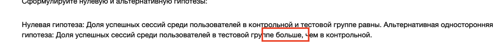

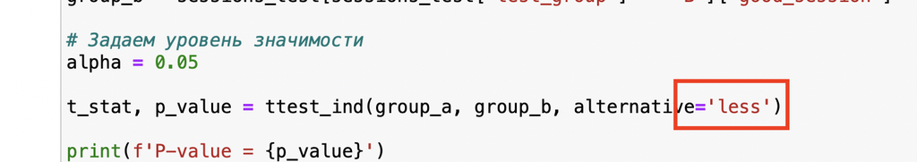

**🔘 Дано**

- B — метрика в **тестовой группе**. Это группа, на которой проводится эксперимент или изменение.
- A — метрика в **контрольной группе**. Это группа, которая не подвергается изменению. Она служит для сравнения, чтобы понять, как изменение в тестовой группе повлияло на результаты.

**Порядок аргументов (имеет значение) - Так должно быть. ✅**

Например, если ты проверяешь: B > A, то порядок аругуметов такой:

`test(B, A, alternative='greater/larger')`

**Тестовая группа идет всегд первой, контрольная второй.**

Если ты случайно поменяешь местами группы, изменится смысл теста.

**Проверка на уменьшение (стало хуже или меньше) - Так сейчас в коде гипотезах. ⚠️**

- H₀: B ≥ A
- H₁: B < A

`test(B, A, alternative='less/smaller')`

Применяй, если ожидаешь, что B меньше чем A.

**Проверка на увеличение (cтало лучше или больше) - Так должно быть. ✅**

- H₀: B ≤ A
- H₁: μA > A

`test(B, A, alternative='greater/larger')`

Применяй, если ожидаешь, что B больше чем A.

💬 Здесь можно оставить комментарий

✅ Молодец.

#### 4.5. Вывод по результатам A/B-эксперимента

На основе проведённого анализа результатов теста сформулируйте и запишите свои выводы для команды разработки приложения. В выводе обязательно укажите:

- Характеристики проведённого эксперимента, количество задействованных пользователей и длительность эксперимента.
- Повлияло ли внедрение нового алгоритма рекомендаций на рост ключевой метрики и как.
- Каким получилось значение p-value для оценки статистической значимости выявленного эффекта.
- Стоит ли внедрять нововведение в приложение.

По результатам тестирования внедрение нового алгоритма рекомендаций положительно повлияло на рост ключевой метрики: количество успешных сессий в тестовой выборке увеличилось примерно на 1.1%, При оценке статистической значимости выявленного эффекта нового алгоритма получилось значение p-value равное 0.00015, что меньше заданного уровня значимости равного 0.05, что говорит о статистически значимом различии между группами А и В.

Результаты проведённого A/B-тестирования продемонстрировали эффективность внедрения нового алгоритма рекомендаций. Этот алгоритм может быть успешно использован для привлечения пользователей, а также для повышения их лояльности и вовлечённости. Полученные данные свидетельствуют о положительном влиянии нововведения на ключевые показатели и подтверждают целесообразность его дальнейшего применения.

##### ✅ Итоговый аналитический вывод

✅ Правильный расчет, понятный и аккуратный вывод. Видно, что метрика улучшилась, и тест это подтвердил, что говорит об успешности A/B-эксперимента! 🎯

💬 Здесь можно оставить комментарий

## 🏁 **Итоги ревью**

В начало

⛔️ Екатерина, спасибо за работу. Осталось исправить несколько комментариев и можно идти к заказчику. Молодец! 👍

Для удобства, комментарии которые нужно скорректировать я добавил в меню **Contents** слева.

Жду новую версию проекта. 🙂

💬 Артем, привет! Спасибо за подробное ревью! Исправила основные недочеты в своей работе, высылаю на повторную проверку.

## ✌️ **Екатерина, поздравляю - проект принят!** 🥳 🎉 Ты умница! 💪 Еще раз спасибо за хорошую работу, твои комментарии и внесенные корректировки! Есть одно критическое замечание, но все остальное ты скорректировала, скорретируй и последний комментарий. Если у тебя есть вопросы, их можно задать через куратора. **Успехов в дальнейшем обучении и карьере! 🚀** **Артем 🤝**

[figure not shown]

--- ## 📖 **Полезные ссылки** * [Работа в Яндексе](https://yandex.ru/jobs/pages/analytics_interview?ysclid=l84s63fs1g790141490) * [Настройте свой Jupyter Notebook правильно](https://medium.com/nuances-of-programming/настройте-свой-jupyter-notebook-правильно-faef14c89434) * [PEP 8 – Style Guide for Python Code](https://www.python.org/dev/peps/pep-0008/) * [Обработка пропусков в данных](https://loginom.ru/blog/missing) * [Разделение данных с помощью qcut и cut в Pandas](https://dfedorov.spb.ru/pandas/Разделение%20данных%20в%20Pandas%20с%20помощью%20qcut%20и%20cut.html?) * [Официальная документаци метода qcut](https://pandas.pydata.org/pandas-docs/stable/reference/api/pandas.qcut.html) * [Подробное руководство по группировке и агрегированию с помощью pandas](https://dfedorov.spb.ru/pandas/Подробное%20руководство%20по%20группировке%20и%20агрегированию%20с%20помощью%20pandas.html?ysclid=lcmm6rtg2w602526506) * [Проверка статистических гипотез. (21 мая 2020 г.)](https://allatambov.github.io/psms/pdf/hypo-test.pdf) * [Шпаргалка по визуализации данных в Python с помощью Plotly](https://habr.com/ru/articles/502958/) * [Тест гигиены визуализации данных](https://bar-or-pie.dianov.org) * [Задачки SQL](https://habr.com/ru/company/dcmiran/blog/500360/) * [7 cайтов для оттачивания навыка написания SQL запросов на 2020 год](https://techrocks.ru/2019/11/22/7-sites-to-perfect-sql-query-writing-skills/) * [Главред помогает очистить текст от словесного мусора, проверяет на соответствие информационному стилю.](https://glvrd.ru)